# Class 5 - Concepts and Cleaning

Colin Kuehl

July 09, 2026

Install and load packages

```r
#install.packages("foreign")
#install.packages("openxlsx")
#install.packages("dplyr") ## This package is used to tidydata. We'll use it later
#install.packages("ggplot2") #Very popular graphing package


library(foreign)
library(dplyr)
library(ggplot2)
library(openxlsx)
```

As always we start with installing and librarying packages. Don’t forget to replace the # after running.

Then set your working directory

```r
setwd("~/Dropbox/POLS 641/CMU Su26/cmucourse26/ClassCode/Day 4")
```

###Cleaning and Organizing data

#Loading Data Today’s second dataset comes directly from the ICPSR(a repository of data from published research) and is an excel format. If we want to we can use a command from the xlsx package(loaded above) to input the data directly.

```r
full <- readWorkbook("energsurv.xlsx", sheet="Data", na.strings = "-9")
```

Packages for importing from excel directly can be finicky(due to microsoft updates etc). Thats ok. It is often easier to just click “save as” in the excel program and save your spreadsheet as a csv. When we do this we can use the read.csv command we’ve used in previous classes.

another note: similar packages exist for important data from STATA, SPSS, SAS, etc. One of the great things about R is its ability work with lots of different types of data.

This is a large dataset and though it has been cleaned by the researcher, we might want to make some changes to make it easier to work with.

First, lets look at the variables we are interested in:

We will use the dyplyr package to tidy the data.

```r
names(full) #The codebook tells us about each variable
```

```
##   [1] "CASEID"                        "CATI_ID"
##   [3] "SURVEY_ITERATION"              "SAMPLE"
##   [5] "GW_BELIEF"                     "BELIEVER_CAUSE"
##   [7] "BELIEVER_CONFIDENCE"           "BELIEVER_FACTOR_ALGORE"
##   [9] "BELIEVER_FACTOR_DROUGHTS"      "BELIEVER_FACTOR_EXTREMES"
##  [11] "BELIEVER_FACTOR_GLACIERS"      "BELIEVER_FACTOR_HURRICANE"
##  [13] "BELIEVER_FACTOR_MILDWINT"      "BELIEVER_FACTOR_MODELS"
##  [15] "BELIEVER_FACTOR_OPEN"          "BELIEVER_FACTOR_OPEN_CODED"
##  [17] "BELIEVER_FACTOR_POLARBRS"      "BELIEVER_FACTOR_WARMER"
##  [19] "BELIEVER_IMMEDIACY"            "BELIEVER_PROBLEM"
##  [21] "NONBELIEVER_CONFIDENCE"        "NONBELIEVER_FACTOR_DISTORT"
##  [23] "NONBELIEVER_FACTOR_OPEN"       "NONBELIEVER_FACTOR_OPEN_CODED"
##  [25] "NONBELIEVER_FACTOR_SCIEVID"    "NONBELIEVER_FACTOR_WEATH"
##  [27] "GW_EARTHTOOBIG"                "GW_KNOWLEDGE"
##  [29] "GW_MEDIAOVERSTATE"             "GW_NATTREND"
```

[output cut: 36 more lines]

```r
Sub1 <- select(full, SURVEY_ITERATION, GW_BELIEF, GW_KNOWLEDGE, FRACKING_EFFECT_ENVIRONMENT, SCIENCE_TRUST,DEMOG_EDU, DEMOG_POLPARTY) #Only pick out variables I'm interested in. Rather than selecting rows(units), select picks out columns(variables)
```

We also can select specified observations. For example, this survey was conducted in two waves. Lets just grab the 2015 wave:

```r
sub15 <- filter(Sub1, SURVEY_ITERATION=="FALL2015") #Again using dplyr dialect
```

Create a second subset for the 08 wave

We can then export this to a different format: (http://www.statmethods.net/input/exportingdata.html)

```r
write.csv(sub15, "envirosurvey15.csv") #This will automatically save to your working directory
```

#Looking at the data

Lets look at the data(using our subset of the 2015 data)

```r
summary(sub15)
```

```
##   SURVEY_ITERATION   GW_BELIEF        GW_KNOWLEDGE FRACKING_EFFECT_ENVIRONMENT
##  Length   :911     Min.   : 1.00   Length   :911   Length   :911
##  N.unique :  1     1st Qu.: 1.00   N.unique :  6   N.unique :  5
##  N.blank  :  0     Median : 1.00   N.blank  :  0   N.blank  :  0
##  Min.nchar:  8     Mean   :13.96   Min.nchar:  1   Min.nchar:  1
##  Max.nchar:  8     3rd Qu.: 2.00   Max.nchar:  2   Max.nchar:  2
##                    Max.   :99.00
##    SCIENCE_TRUST   DEMOG_EDU      DEMOG_POLPARTY
##  Length   :911   Min.   : 1.000   Min.   : 1.00
##  N.unique :  6   1st Qu.: 2.000   1st Qu.: 1.00
##  N.blank  :  0   Median : 3.000   Median : 2.00
##  Min.nchar:  1   Mean   : 4.162   Mean   :10.46
##  Max.nchar:  2   3rd Qu.: 4.000   3rd Qu.: 4.00
##                  Max.   :99.000   Max.   :99.00
```

```r
dim(sub15)
```

```
## [1] 911   7
```

A specific variable

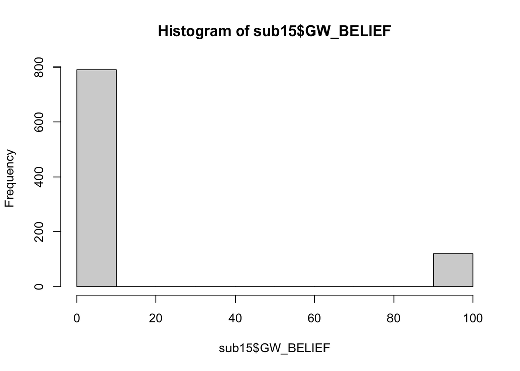

```r
hist(sub15$GW_BELIEF) #Whats wrong with this picture?
```

```r
table(sub15$GW_BELIEF) #Need to look at codebook to understand what is going on
```

```
##
##   1   2  98  99
## 627 164 119   1
```

Change values within a single variable

Recode 98 and 99 to NA

```r
sub15$GW_BELIEF[sub15$GW_BELIEF==98] <- NA
sub15$GW_BELIEF[sub15$GW_BELIEF==99] <- NA

data15 <- sub15 #Copy dataset(I always create a copy when initially tidying so I don't alter the original)

data15 [data15 ==98] <- NA #Converts across the entire dataset
data15 [data15 ==99] <- NA
```

Clearly knowing not recoding for NA will be a major problem. We’ll talk about how to handle missing data later.

Check new histogram and frequency

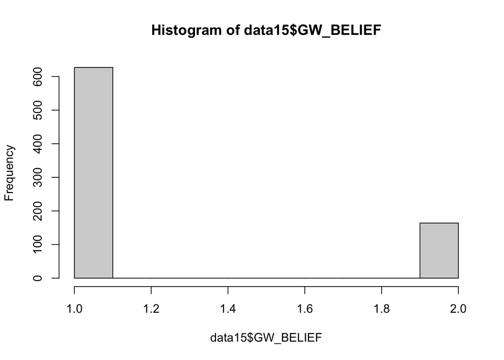

```r
hist(data15$GW_BELIEF) #Ugly, but its right. What does 1 equal? We need to reference the codebook.
```

```r
prop.table(table(data15$GW_BELIEF))
```

```
##
##         1         2
## 0.7926675 0.2073325
```

Look at different variable

```r
hist(data15$FRACKING_EFFECT_ENVIRONMENT) #gives an error -  'x' must be numeric

str(data15$FRACKING_EFFECT_ENVIRONMENT) #R thinks it is a character variable


data15$frackingeffect <- as.numeric(data15$FRACKING_EFFECT_ENVIRONMENT)
hist(data15$frackingeffect) # This actually isn't a continuous varible.
```

- character - equivalent to categorical
- numeric (real or decimal) - equivalent to continuous
- integer - equivalent to continuous
- logical - True or false, ie binary
- complex - complex numbers, I’ve never actually seen

Change from numeric to labeled character

```r
sub15$frackfactor <- sub15$frackfactor <- case_when(
  sub15$FRACKING_EFFECT_ENVIRONMENT == "1"  ~ "Positive Effect",
  sub15$FRACKING_EFFECT_ENVIRONMENT == "2"  ~ "Negative Effect",
  sub15$FRACKING_EFFECT_ENVIRONMENT == "3"  ~ "No Effect",
  sub15$FRACKING_EFFECT_ENVIRONMENT == "98" ~ "Not Sure",
  sub15$FRACKING_EFFECT_ENVIRONMENT == "99" ~ "Refused"
)

table(sub15$frackfactor)
```

```
##
## Negative Effect       No Effect        Not Sure Positive Effect         Refused
##             473             115             225              96               2
```

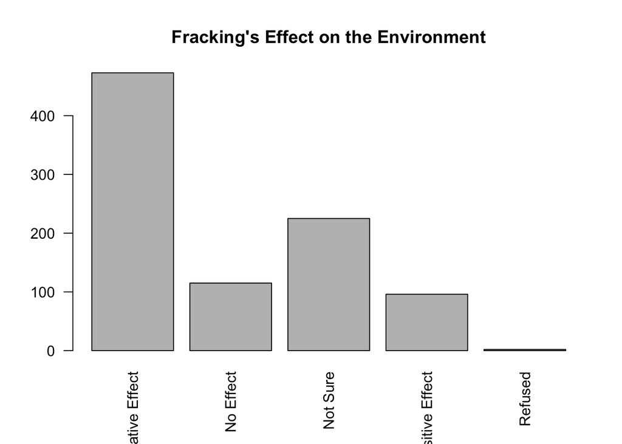

```r
barplot(table(sub15$frackfactor), main="Fracking's Effect on the Environment", las=2)
```

We could also convert this ordinal variable to a binary using the ifelse command

```r
table(sub15$FRACKING_EFFECT_ENVIRONMENT)#looking at data again
```

```
##
##   1   2   3  98  99
##  96 473 115 225   2
```

```r
sub15$frackbi <- ifelse(sub15$FRACKING_EFFECT_ENVIRONMENT==1, "Positive", "Other")
table(sub15$frackbi)
```

```
##
##    Other Positive
##      815       96
```

Lets compare perceptions of fracking effect by party

```r
table(sub15$DEMOG_POLPARTY)# we can look at the codebook to understand what these terms mean.
```

```
##
##   1   2   3   4  98  99
## 292 242  36 264  32  45
```

```r
sub15$party <- case_when(
  sub15$DEMOG_POLPARTY %in% c(98, 99) ~ NA_character_,
  sub15$DEMOG_POLPARTY == 1           ~ "Democrat",
  sub15$DEMOG_POLPARTY == 2           ~ "Republican",
  sub15$DEMOG_POLPARTY %in% c(3, 4)   ~ "Other"
)#use casewhen to make meaninful

table(sub15$frackfactor, sub15$party) #Raw counts: rows = fracking view, columns = party
```

```
##
##                   Democrat Other Republican
##   Negative Effect      180   173         95
##   No Effect             22    40         49
##   Not Sure              60    66         64
##   Positive Effect       29    21         34
##   Refused                1     0          0
```

```r
#Counts are hard to compare when groups differ in size. Convert to proportions:
crosstab <- table(sub15$frackfactor, sub15$party)

prop.table(crosstab)            #Each cell as share of ALL respondents
```

```
##
##                      Democrat       Other  Republican
##   Negative Effect 0.215827338 0.207434053 0.113908873
##   No Effect       0.026378897 0.047961631 0.058752998
##   Not Sure        0.071942446 0.079136691 0.076738609
##   Positive Effect 0.034772182 0.025179856 0.040767386
##   Refused         0.001199041 0.000000000 0.000000000
```

```r
prop.table(crosstab, margin=2)  #Each cell as share of its COLUMN (within party)
```

```
##
##                      Democrat       Other  Republican
##   Negative Effect 0.616438356 0.576666667 0.392561983
##   No Effect       0.075342466 0.133333333 0.202479339
##   Not Sure        0.205479452 0.220000000 0.264462810
##   Positive Effect 0.099315068 0.070000000 0.140495868
##   Refused         0.003424658 0.000000000 0.000000000
```

```r
round(prop.table(crosstab, margin=2), 2) #Rounded - much easier to read
```

```
##
##                   Democrat Other Republican
##   Negative Effect     0.62  0.58       0.39
##   No Effect           0.08  0.13       0.20
##   Not Sure            0.21  0.22       0.26
##   Positive Effect     0.10  0.07       0.14
##   Refused             0.00  0.00       0.00
```

```r
#Question for class: why is margin=2 the right choice here?
#(Hint: we want to compare parties, so each party's column should sum to 1)
```

Similarly we can use group_by to get stats for different groups.

```r
sub15 %>%
  group_by(party) %>%
  summarise(mean_belief = mean(GW_BELIEF, na.rm=TRUE),
            sd_belief   = sd(GW_BELIEF, na.rm=TRUE),
            respondents = n())
```

```
## # A tibble: 4 × 4
##   party      mean_belief sd_belief respondents
##   <chr>            <dbl>     <dbl>       <int>
## 1 Democrat          1.12     0.325         292
## 2 Other             1.22     0.412         300
## 3 Republican        1.33     0.473         242
## 4 <NA>              1.12     0.333          77
```

Look at science trust. What type of variable is this? How might we make it more usable?

Double bonus/optional: Use find and replace to do the same with your 08 dataset

If its justified, we can also just create a new dataset of complete cases

```r
sub15na <- na.omit(sub15)
```

You will likely spend as much, if not more, time cleaning and organizing your data to make it useful as you do actually running models. There are many more issues you will deal with than can be explained here, or in resources, but googling is often very helpful.